# Project 7 - AllLife Bank Customer Segmentation - Andrew Susanto

## Background

### Context

AllLife Bank wants to focus on its credit card customer base in the next financial year. They have been advised by their marketing research team, that the penetration in the market can be improved. Based on this input, the Marketing team proposes to run personalized campaigns to target new customers as well as upsell to existing customers. Another insight from the market research was that the customers perceive the support services of the back poorly. Based on this, the Operations team wants to upgrade the service delivery model, to ensure that customer queries are resolved faster. Head of Marketing and Head of Delivery both decide to reach out to the Data Science team for help

### Objective

To identify different segments in the existing customer, based on their spending patterns as well as past interaction with the bank, using clustering algorithms, and provide recommendations to the bank on how to better market to and service these customers.

### Data Description

The data provided is of various customers of a bank and their financial attributes like credit limit, the total number of credit cards the customer has, and different channels through which customers have contacted the bank for any queries (including visiting the bank, online and through a call center).

### Data Dictionary

Sl_No: Primary key of the records

Customer Key: Customer identification number

Average Credit Limit: Average credit limit of each customer for all credit cards

Total credit cards: Total number of credit cards possessed by the customer

Total visits bank: Total number of Visits that customer made (yearly) personally to the bank

Total visits online: Total number of visits or online logins made by the customer (yearly)

Total calls made: Total number of calls made by the customer to the bank or its customer service department (yearly)

### Problem Statement

From the information provided above, we are required to identify segments within the existing customer data provided based on factors as per the data dictionary. Upon identification, we are required to provide recommendations to the bank on which segment is best to be approached. In addition to that, separate strategies for different segments can be provided as well.

## Data Importing & Preparation

```python
#importing of required libraries
import pandas as pd
import numpy as np
import seaborn as sns
import matplotlib.pyplot as plt
%matplotlib inline

#import library to ignore warnings
import warnings
warnings.filterwarnings('ignore')
```

```python
# to scale the data using z-score
from sklearn.preprocessing import StandardScaler

# to compute distances
from scipy.spatial.distance import cdist

# to perform k-means clustering and compute silhouette scores
from sklearn.cluster import KMeans
from sklearn.metrics import silhouette_score
```

```python
# to compute distances
from scipy.spatial.distance import pdist

# to perform hierarchical clustering, compute cophenetic correlation, and create dendrograms
from sklearn.cluster import AgglomerativeClustering
from scipy.cluster.hierarchy import dendrogram, linkage, cophenet
```

```python
#importing of data
df = pd.read_excel('Credit Card Customer Data.xlsx')
```

```python
#checking on first 5 data
df.head()
```

|  | Sl_No | Customer Key | Avg_Credit_Limit | Total_Credit_Cards | Total_visits_bank | Total_visits_online | Total_calls_made |
| --- | --- | --- | --- | --- | --- | --- | --- |
| 0 | 1 | 87073 | 100000 | 2 | 1 | 1 | 0 |
| 1 | 2 | 38414 | 50000 | 3 | 0 | 10 | 9 |
| 2 | 3 | 17341 | 50000 | 7 | 1 | 3 | 4 |
| 3 | 4 | 40496 | 30000 | 5 | 1 | 1 | 4 |
| 4 | 5 | 47437 | 100000 | 6 | 0 | 12 | 3 |

```python
#checking on last 5 data
df.tail()
```

|  | Sl_No | Customer Key | Avg_Credit_Limit | Total_Credit_Cards | Total_visits_bank | Total_visits_online | Total_calls_made |
| --- | --- | --- | --- | --- | --- | --- | --- |
| 655 | 656 | 51108 | 99000 | 10 | 1 | 10 | 0 |
| 656 | 657 | 60732 | 84000 | 10 | 1 | 13 | 2 |
| 657 | 658 | 53834 | 145000 | 8 | 1 | 9 | 1 |
| 658 | 659 | 80655 | 172000 | 10 | 1 | 15 | 0 |
| 659 | 660 | 80150 | 167000 | 9 | 0 | 12 | 2 |

```python
#checking data shape
df.shape
```

```
(660, 7)
```

```python
#checking data info (data type, non-null count info)
df.info()
```

```
<class 'pandas.core.frame.DataFrame'>
RangeIndex: 660 entries, 0 to 659
Data columns (total 7 columns):
 #   Column               Non-Null Count  Dtype
---  ------               --------------  -----
 0   Sl_No                660 non-null    int64
 1   Customer Key         660 non-null    int64
 2   Avg_Credit_Limit     660 non-null    int64
 3   Total_Credit_Cards   660 non-null    int64
 4   Total_visits_bank    660 non-null    int64
 5   Total_visits_online  660 non-null    int64
 6   Total_calls_made     660 non-null    int64
dtypes: int64(7)
memory usage: 36.2 KB
```

```python
#checking possible duplicates
df[df['Customer Key'].duplicated(keep=False) == True].sort_values(by=['Customer Key'])
```

|  | Sl_No | Customer Key | Avg_Credit_Limit | Total_Credit_Cards | Total_visits_bank | Total_visits_online | Total_calls_made |
| --- | --- | --- | --- | --- | --- | --- | --- |
| 48 | 49 | 37252 | 6000 | 4 | 0 | 2 | 8 |
| 432 | 433 | 37252 | 59000 | 6 | 2 | 1 | 2 |
| 4 | 5 | 47437 | 100000 | 6 | 0 | 12 | 3 |
| 332 | 333 | 47437 | 17000 | 7 | 3 | 1 | 0 |
| 411 | 412 | 50706 | 44000 | 4 | 5 | 0 | 2 |
| 541 | 542 | 50706 | 60000 | 7 | 5 | 2 | 2 |
| 391 | 392 | 96929 | 13000 | 4 | 5 | 0 | 0 |
| 398 | 399 | 96929 | 67000 | 6 | 2 | 2 | 2 |
| 104 | 105 | 97935 | 17000 | 2 | 1 | 2 | 10 |
| 632 | 633 | 97935 | 187000 | 7 | 1 | 7 | 0 |

```python
#checking possible duplicates
df[df['Sl_No'].duplicated(keep=False) == True].sort_values(by=['Sl_No'])
```

|  | Sl_No | Customer Key | Avg_Credit_Limit | Total_Credit_Cards | Total_visits_bank | Total_visits_online | Total_calls_made |
| --- | --- | --- | --- | --- | --- | --- | --- |

As per analysis above, we can see that there are duplicate values for Customer Key. However, the values for the data with duplicated Customer Key are different, hence it does not seem that they are duplicated data. Hence we decided to keep the data as it is.

Sl_No and Customer Key must be removed as they are unique identifiers and do not contribute to analysis of the data.

```python
#dropping of Sl_No and Customer Key columns
df.drop('Sl_No',axis = 1,inplace=True)
df.drop('Customer Key',axis = 1,inplace=True)
```

```python
#checking if unique identifiers have been removed
df.head()
```

|  | Avg_Credit_Limit | Total_Credit_Cards | Total_visits_bank | Total_visits_online | Total_calls_made |
| --- | --- | --- | --- | --- | --- |
| 0 | 100000 | 2 | 1 | 1 | 0 |
| 1 | 50000 | 3 | 0 | 10 | 9 |
| 2 | 50000 | 7 | 1 | 3 | 4 |
| 3 | 30000 | 5 | 1 | 1 | 4 |
| 4 | 100000 | 6 | 0 | 12 | 3 |

```python
#checking on statistics of each column
df.describe(include='all')
```

|  | Avg_Credit_Limit | Total_Credit_Cards | Total_visits_bank | Total_visits_online | Total_calls_made |
| --- | --- | --- | --- | --- | --- |
| count | 660.000000 | 660.000000 | 660.000000 | 660.000000 | 660.000000 |
| mean | 34574.242424 | 4.706061 | 2.403030 | 2.606061 | 3.583333 |
| std | 37625.487804 | 2.167835 | 1.631813 | 2.935724 | 2.865317 |
| min | 3000.000000 | 1.000000 | 0.000000 | 0.000000 | 0.000000 |
| 25% | 10000.000000 | 3.000000 | 1.000000 | 1.000000 | 1.000000 |
| 50% | 18000.000000 | 5.000000 | 2.000000 | 2.000000 | 3.000000 |
| 75% | 48000.000000 | 6.000000 | 4.000000 | 4.000000 | 5.000000 |
| max | 200000.000000 | 10.000000 | 5.000000 | 15.000000 | 10.000000 |

Using the df.info() and df.describe() function, it can be seen that there are no missing data (it's possible for the values to be 0). Let's see further on the data using univariate and bivariate analysis.

## Exploratory Data Analysis

### Univariate Analysis

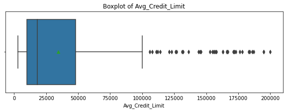

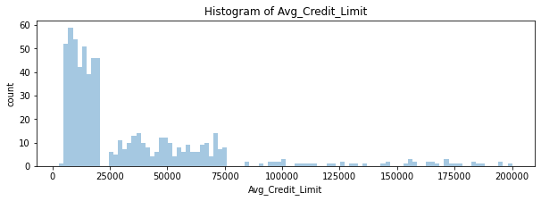

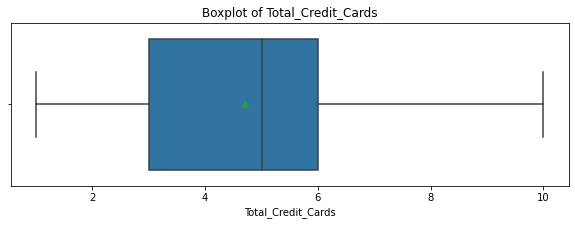

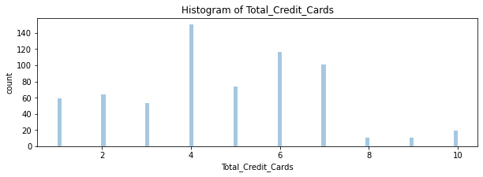

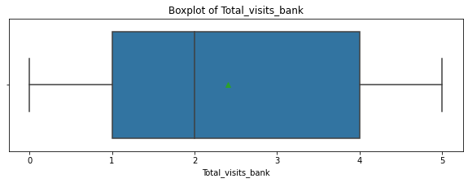

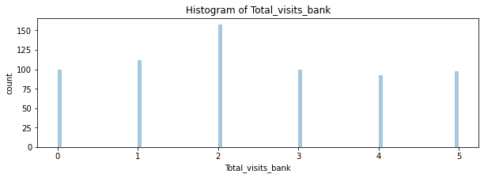

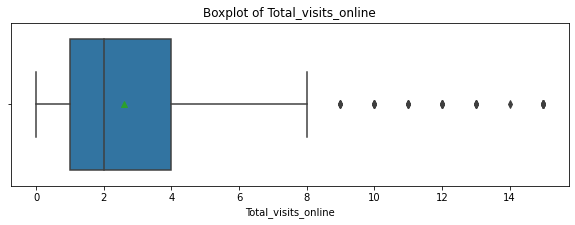

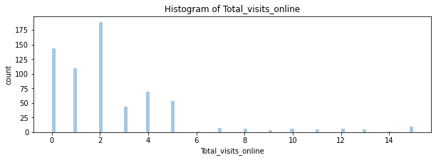

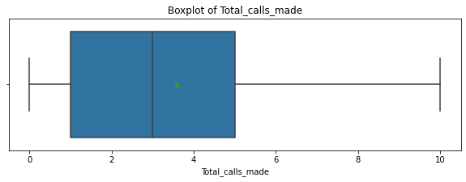

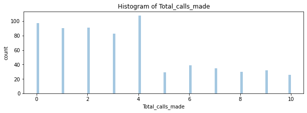

```python
#function to show boxplot and histogram of each column

for b in df.columns:
    plt.figure(figsize=(10, 3))
    sns.boxplot(df[b], showmeans=True)
    plt.title('Boxplot of {}'.format(b))
    plt.show()
    plt.figure(figsize=(10, 3))
    sns.distplot(df[b], kde = False, bins = 100)
    plt.title('Histogram of {}'.format(b))
    plt.ylabel('count')
    plt.show()
```

From univariate analysis, it can be seen that:

1. Avg_Credit_Limit data is right skewed. The mean of the data is around 35000.
2. Total_Credit_Cards data is a bit right skewed. The range of the data is 1 to 10.
3. Total_visits_bank data is somewhat normally distributed. The range of the data is 0 to 5.
4. Total_visits_online data is right skewed. The range of the data is 0 to 15.
5. Total_calls_made is right skewed. The range of the data is 0 to 10.

### Bivariate Analysis

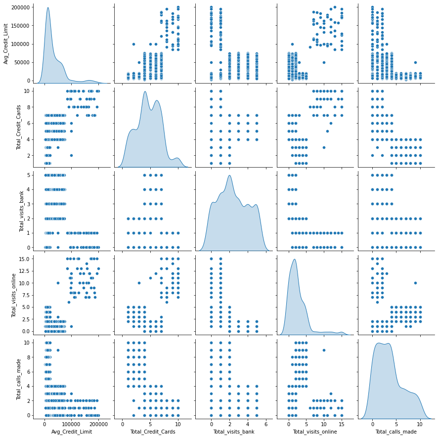

```python
#plotting pairplot between columns
sns.pairplot(df,diag_kind='kde')
```

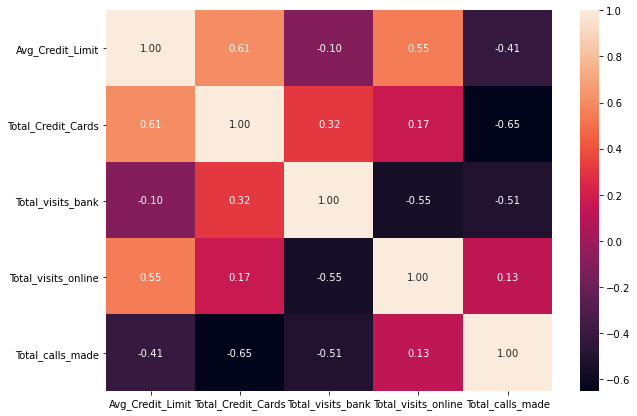

```python
#plotting of heatmap to check on correlation between data
plt.figure(figsize=(10, 7))
sns.heatmap(df.corr(), annot=True, fmt='.2f',)
plt.show()
```

From bivariate analysis, it can be seen that variables that are positively correlated are:

1. Total_Credit_Cards and Avg_Credit_Limit, which is to be expected.
2. Total_visits_online and Avg_Credit_Limit

From bivariate analysis, it can be seen that variables that are inversely/negatively correlated are:

1. Total_calls_made and Total_Credit_Cards. This could show that customers with few credit cards are more particular and make queries to the bank more often than those with lots of credit cards.
2. Total_visits_online and Total_visits_bank, which is to be expected. Customers who used the services online no longer need to visit the bank. On the other way around, there are customers who are not used to using online services and prefer to visit a teller.
3. Total_calls_made and Total_visits_bank, which is to be expected. Those who have their queries solved via phone no longer need to visit the bank physically. On the other way, some customers prefer to meet face to face.

From the pairplot, it can be seen that there are at least 2 clusters visible (from Total_Credit_Cards and Avg_Credit_Limit, as well as Total_visits_online and Avg_Credit_Limit). However, the pairplot can only compare two dimensions at a time, and there is a possibility that more than 2 clusters are formed.

## Data Preparation

It has been noted that there are no missing data and we decided to keep the extreme values as they could be part of a certain group/segment. Unique identifier columns such as Sl_No and Customer Key have been removed.

However, Avg_Credit_Limit has very large values and variations as compared to the other columns. We need to apply scaler to the dataset to standardize them for analysis later.

```python
#importing and application of scaling

from scipy.stats import zscore

dfscaled = df.apply(zscore)
```

```python
# #StandardScaler can also be used to scale the data

# scaler = StandardScaler()
# dfscaled2 = scaler.fit_transform(df)
# newdf = pd.DataFrame(dfscaled2, columns=df.columns)
# newdf
```

```python
#checking on the values
dfscaled.head()
```

|  | Avg_Credit_Limit | Total_Credit_Cards | Total_visits_bank | Total_visits_online | Total_calls_made |
| --- | --- | --- | --- | --- | --- |
| 0 | 1.740187 | -1.249225 | -0.860451 | -0.547490 | -1.251537 |
| 1 | 0.410293 | -0.787585 | -1.473731 | 2.520519 | 1.891859 |
| 2 | 0.410293 | 1.058973 | -0.860451 | 0.134290 | 0.145528 |
| 3 | -0.121665 | 0.135694 | -0.860451 | -0.547490 | 0.145528 |
| 4 | 1.740187 | 0.597334 | -1.473731 | 3.202298 | -0.203739 |

There should be no difference in the plotting results for univariate/bivariate analysis. We can prove it as per below:

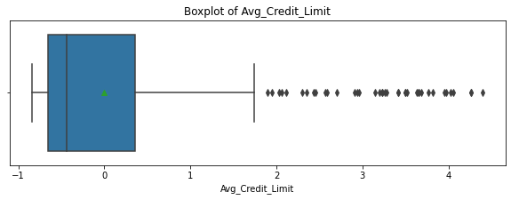

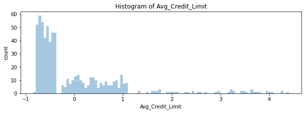

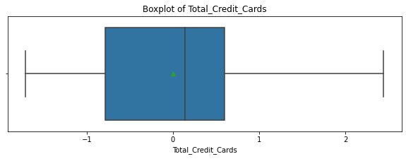

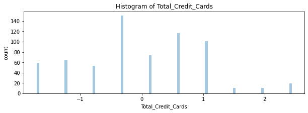

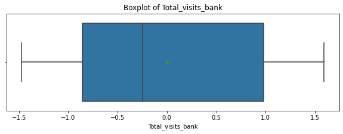

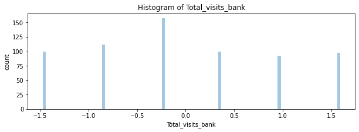

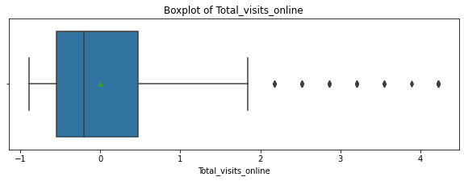

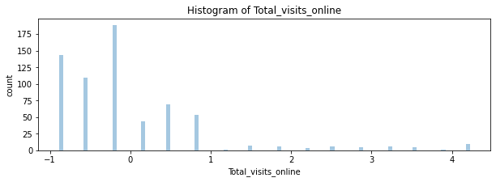

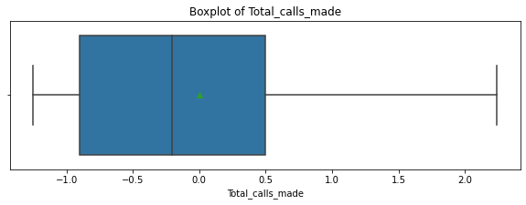

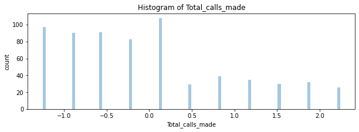

```python
#univariate analysis

for b in dfscaled.columns:
    plt.figure(figsize=(10, 3))
    sns.boxplot(dfscaled[b], showmeans=True)
    plt.title('Boxplot of {}'.format(b))
    plt.show()
    plt.figure(figsize=(10, 3))
    sns.distplot(dfscaled[b], kde = False, bins = 100)
    plt.title('Histogram of {}'.format(b))
    plt.ylabel('count')
    plt.show()

#the distribution should be similar
```

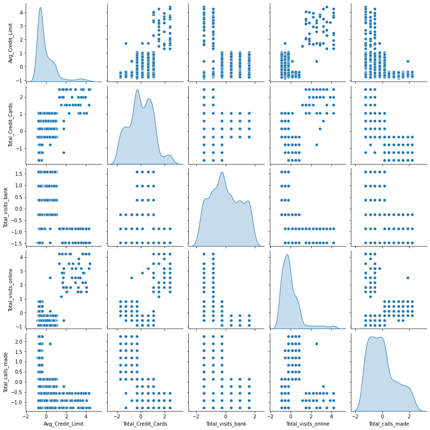

```python
#bivariate analysis
sns.pairplot(dfscaled,diag_kind='kde')
```

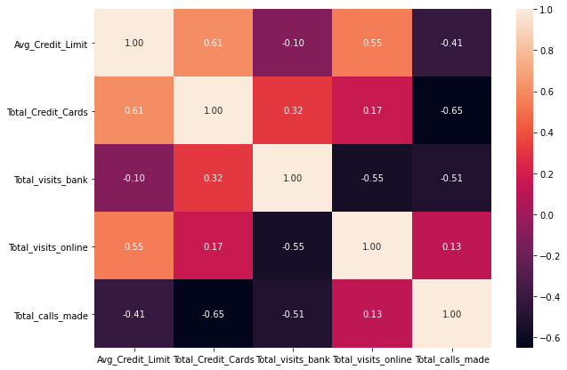

```python
#plotting of heatmap to check on correlation between data
plt.figure(figsize=(10, 7))
sns.heatmap(dfscaled.corr(), annot=True, fmt='.2f',)
plt.show()
```

As per above, we can see that there are no changes in the plots for univariate/bivariate analysis after scaling of the data.